# **Music Recommendation System**

### Model Based Collaborative Filtering - Matrix Factorization

Model-based Collaborative Filtering is a **personalized recommendation system**, the recommendations are based on the past behavior of the user and it is not dependent on any additional information. We use **latent features** to find recommendations for each user.

```python
# Build baseline model using svd

# Using SVD with matrix factorization
svd = SVD(random_state = 1)

# Training the algorithm on the training dataset
svd.fit(trainset)
```

```
<surprise.prediction_algorithms.matrix_factorization.SVD at 0x7b83a4ab5a80>
```

```python
# Let us compute precision@k and recall@k also with k =30
precision, recall, f1, rmse = precision_recall_at_k(svd)

# Save the model's info
svd_params = f"'n_epochs':{svd.n_epochs}, 'lr':{svd.lr_bu}, 'reg':{svd.reg_bu}"
add_model_record(df_model_info, 'SVD', svd_params, precision, recall, f1, rmse)
```

```
RMSE: 1.0252
Precision:  0.40966595
Recall:  0.6331272
F_1 score:  0.4974537
```

```python
# Making prediction for user (with user_id 6958) to song (with song_id 1671), take r_ui = 2
svd.predict(6958, 1671, r_ui = 2, verbose = True)
```

```
user: 6958       item: 1671       r_ui = 2.00   est = 1.27   {'was_impossible': False}
```

```
Prediction(uid=6958, iid=1671, r_ui=2, est=1.267473397214638, details={'was_impossible': False})
```

```python
# Making a prediction for the user who has not listened to the song (song_id 3232)
svd.predict(6958, 3232, verbose = True)
```

```
user: 6958       item: 3232       r_ui = None   est = 1.56   {'was_impossible': False}
```

```
Prediction(uid=6958, iid=3232, r_ui=None, est=1.5561675084403663, details={'was_impossible': False})
```

#### Improving matrix factorization based recommendation system by tuning its hyperparameters

```python
# Set the parameter space to tune
param_grid = {'n_epochs': [10, 20, 30], 'lr_all': [0.001, 0.005, 0.01],
              'reg_all': [0.2, 0.4, 0.6]}

# Performe 3-fold grid-search cross-validation
gs = GridSearchCV(SVD, param_grid, measures = ['rmse'], cv = 3, n_jobs = -1)

# Fitting data
gs.fit(data)

# Best RMSE score
print(gs.best_score['rmse'])

# Combination of parameters that gave the best RMSE score
print(gs.best_params['rmse'])
```

```
1.01168133604315
{'n_epochs': 30, 'lr_all': 0.01, 'reg_all': 0.2}
```

**Think About It**: How do the parameters affect the performance of the model? Can we improve the performance of the model further? Check the available hyperparameters [here](https://surprise.readthedocs.io/en/stable/matrix_factorization.html).

- The number of iterations (epochs) controls the number of times the model updates its parameters based on the training data. It can affect the model's convergence, risk of overfitting, computational cost, and overall performance.
- The learning rate determines the size of the steps taken during optimization. A too high or too low learning rate can lead to convergence issues or slow convergence, respectively. Optimizing the learning rate is crucial for achieving good performance.
- Regularization strength for all parameters helps prevent overfitting by penalizing large parameter values. A higher regularization strength encourages simpler models with smaller parameter values, reducing the risk of overfitting. The choice of an appropriate regularization strength depends on the specific dataset and the trade-off between bias and variance.

```python
# Building the optimized SVD model using optimal hyperparameters
svd_optimized = SVD(n_epochs = 30, lr_all = 0.01, reg_all = 0.2, random_state = 1)

# Training the algorithm on the train set
svd_optimized = svd_optimized.fit(trainset)
```

```python
# Let us compute precision@k and recall@k also with k =30
precision, recall, f1, rmse = precision_recall_at_k(svd_optimized)

# Save the model's info
svd_optimized_params = gs.best_params
add_model_record(df_model_info, 'SVD Optimized', svd_optimized_params, precision, recall, f1, rmse)
```

```
RMSE: 1.0141
Precision:  0.41450246
Recall:  0.63477746
F_1 score:  0.50151883
```

**Observations and Insights:**

- We can observe that after tuning hyperparameters, **F_1 score, Precision and Recall of the model are all slightly better than the baseline model**. Along with this, **the RMSE of the model has gone down a little bit in comparison to the model with default hyperparameters**. Hence, we can say that the model performance has improved after hyperparameter tuning.

```python
# Using svd_algo_optimized model to recommend for userId 6958 and song_id 1671
svd_optimized.predict(6958, 1671, r_ui = 2, verbose = True)
```

```
user: 6958       item: 1671       r_ui = 2.00   est = 1.34   {'was_impossible': False}
```

```
Prediction(uid=6958, iid=1671, r_ui=2, est=1.3432395286125098, details={'was_impossible': False})
```

```python
# Using svd_algo_optimized model to recommend for userId 6958 and song_id 3232 with unknown baseline play_count
svd_optimized.predict(6958, 3232, verbose = True)
```

```
user: 6958       item: 3232       r_ui = None   est = 1.44   {'was_impossible': False}
```

```
Prediction(uid=6958, iid=3232, r_ui=None, est=1.4425484461176483, details={'was_impossible': False})
```

**Observations and Insights:**

- The predicted play counts are close to the baseline model. Although the overall score has increased a little bit, the prediction for this particular user is still not that good.

```python
# Getting top 5 recommendations for user_id 6958 using "svd_optimized" algorithm
svd_recommendations = get_recommendations(df_final, 6958, 5, svd_optimized)
```

```python
# Ranking songs based on above recommendations
ranking_songs(svd_recommendations, final_play)
```

|  | song_id | play_freq | predicted_play_count | corrected_play_count |
| --- | --- | --- | --- | --- |
| 2 | 7224 | 107 | 2.601899 | 2.505225 |
| 1 | 5653 | 108 | 2.108728 | 2.012502 |
| 4 | 8324 | 96 | 2.014091 | 1.912029 |
| 0 | 9942 | 150 | 1.940115 | 1.858465 |
| 3 | 6450 | 102 | 1.952493 | 1.853478 |

**Observations and Insights:*

- We use the make top n recommendations function for the same user with the new fitted model. It recommended different songs.
- The ranking_song function is used on this new set of recommended songs and returned the corrected play count.

### Cluster Based Recommendation System

In **clustering-based recommendation systems**, we explore the **similarities and differences** in people's tastes in songs based on how they rate different songs. We cluster similar users together and recommend songs to a user based on play_counts from other users in the same cluster.

```python
# Make baseline clustering model

# Using CoClustering algorithm
clust_baseline = CoClustering(random_state = 1)

# Training the algorithm on the train set
clust_baseline.fit(trainset)
```

```
<surprise.prediction_algorithms.co_clustering.CoClustering at 0x7b83065d4640>
```

```python
# Let us compute precision@k and recall@k also with k =30
precision, recall, f1, rmse = precision_recall_at_k(clust_baseline)

# Save the model's info
clust_baseline_params = f"n_cltr_u: {clust_baseline.n_cltr_u}, n_cltr_i: {clust_baseline.n_cltr_i}, n_epochs: {clust_baseline.n_epochs}"
add_model_record(df_model_info, 'Cluster Based', clust_baseline_params, precision, recall, f1, rmse)
```

```
RMSE: 1.0487
Precision:  0.39655778
Recall:  0.58203924
F_1 score:  0.4717206
```

```python
# Making prediction for user_id 6958 and song_id 1671
clust_baseline.predict(6958, 1671, r_ui = 2, verbose = True)
```

```
user: 6958       item: 1671       r_ui = 2.00   est = 1.29   {'was_impossible': False}
```

```
Prediction(uid=6958, iid=1671, r_ui=2, est=1.2941824757363074, details={'was_impossible': False})
```

```python
# Making prediction for user (userid 6958) for a song(song_id 3232) not listened to by the user
clust_baseline.predict(6958, 3232, verbose = True)
```

```
user: 6958       item: 3232       r_ui = None   est = 1.48   {'was_impossible': False}
```

```
Prediction(uid=6958, iid=3232, r_ui=None, est=1.4785259100797417, details={'was_impossible': False})
```

#### Improving clustering-based recommendation system by tuning its hyper-parameters

```python
# Set the parameter space to tune
param_grid = {'n_cltr_u': [3, 4, 5, 6], 'n_cltr_i': [3, 4, 5, 6], 'n_epochs': [30, 40, 50]}

# Performing 3-Fold gridsearch cross-validation
gs = GridSearchCV(CoClustering, param_grid, measures = ['rmse'], cv = 3, n_jobs = -1)

# Fitting data
gs.fit(data)

# Printing the best RMSE score
print(gs.best_score['rmse'])

# Printing the combination of parameters that gives the best RMSE score
print(gs.best_params['rmse'])
```

```
1.0455185471691755
{'n_cltr_u': 3, 'n_cltr_i': 3, 'n_epochs': 50}
```

**Think About It**: How do the parameters affect the performance of the model? Can we improve the performance of the model further? Check the available hyperparameters [here](https://surprise.readthedocs.io/en/stable/co_clustering.html).

```python
# Train the tuned Coclustering algorithm
# Using tuned Coclustering algorithm
clust_tuned = CoClustering(n_cltr_u = 3, n_cltr_i = 5, n_epochs = 50, random_state = 1)

# Training the algorithm on the train set
clust_tuned.fit(trainset)
```

```
<surprise.prediction_algorithms.co_clustering.CoClustering at 0x7b83065d7d00>
```

```python
# Let us compute precision@k and recall@k also with k =30
precision, recall, f1, rmse = precision_recall_at_k(clust_tuned)

# Save the model's info
clust_tuned_params = gs.best_params
add_model_record(df_model_info, 'Cluster Tuned', clust_tuned_params, precision, recall, f1, rmse)
```

```
RMSE: 1.0568
Precision:  0.39202878
Recall:  0.57198645
F_1 score:  0.4652108
```

```python
# Check the model info dataframe
df_model_info
```

|  | Model Type | Parameters | Precision | Recall | F1 | RMSE | Combination |
| --- | --- | --- | --- | --- | --- | --- | --- |
| 0 | User-User | k=40, min_k=1, sim_options={'name': 'cosine', ... | 0.396197 | 0.691995 | 0.503894 | 1.087823 |  |
| 1 | User-User Optimized | k=50, min_k=9, sim_options={'name': 'msd', 'us... | 0.414300 | 0.623366 | 0.497772 | 1.059632 |  |
| 2 | Item-Item | k=40, min_k=1, sim_options={'name': 'cosine', ... | 0.306800 | 0.561836 | 0.396878 | 1.039363 |  |
| 3 | Item-Item Optimized | k=40, min_k=6, sim_options={'name': 'msd', 'us... | 0.336465 | 0.565642 | 0.421943 | 1.041560 |  |
| 4 | SVD | 'n_epochs':20, 'lr':0.005, 'reg':0.02 | 0.409666 | 0.633127 | 0.497454 | 1.025249 |  |
| 5 | SVD Optimized | {'rmse': {'n_epochs': 30, 'lr_all': 0.01, 'reg... | 0.414502 | 0.634777 | 0.501519 | 1.014134 |  |
| 6 | Cluster Based | n_cltr_u: 3, n_cltr_i: 3, n_epochs: 20 | 0.396558 | 0.582039 | 0.471721 | 1.048667 |  |
| 7 | Cluster Tuned | {'rmse': {'n_cltr_u': 3, 'n_cltr_i': 3, 'n_epo... | 0.392029 | 0.571986 | 0.465211 | 1.056770 |  |

**Observations and Insights:**

```python
# Using co_clustering_optimized model to recommend for userId 6958 and song_id 1671
clust_tuned.predict(6958, 1671, r_ui = 2, verbose = True)
```

```
user: 6958       item: 1671       r_ui = 2.00   est = 1.69   {'was_impossible': False}
```

```
Prediction(uid=6958, iid=1671, r_ui=2, est=1.6949601801372254, details={'was_impossible': False})
```

```python
# Use Co_clustering based optimized model to recommend for userId 6958 and song_id 3232 with unknown baseline play_count
clust_tuned.predict(6958, 3232, verbose = True)
```

```
user: 6958       item: 3232       r_ui = None   est = 1.88   {'was_impossible': False}
```

```
Prediction(uid=6958, iid=3232, r_ui=None, est=1.87930361448066, details={'was_impossible': False})
```

**Observations and Insights:**

- The prediction for this particular user is still not that good.

#### Implementing the recommendation algorithm based on optimized CoClustering model

```python
# Getting top 5 recommendations for user_id 6958 using "Co-clustering based optimized" algorithm
clustering_recommendations = get_recommendations(df_final, 6958, 5, clust_tuned)
```

### Correcting the play_count and Ranking the above songs

```python
# Ranking songs based on the above recommendations
ranking_songs(clustering_recommendations, final_play)
```

|  | song_id | play_freq | predicted_play_count | corrected_play_count |
| --- | --- | --- | --- | --- |
| 4 | 8324 | 96 | 2.712276 | 2.610214 |
| 2 | 7224 | 107 | 2.614171 | 2.517497 |
| 3 | 4831 | 97 | 2.524561 | 2.423026 |
| 0 | 6246 | 422 | 2.409936 | 2.361257 |
| 1 | 8483 | 123 | 2.366879 | 2.276712 |

**Observations and Insights:**

### Content Based Recommendation Systems

**Think About It:** So far we have only used the play_count of songs to find recommendations but we have other information/features on songs as well. Can we take those song features into account?

```python
# Concatenate the "title", "release", "artist_name" columns to create a different column named "text"
df_final['text'] = df_final['title'] + ' ' + df_final['release'] + ' ' + df_final['artist_name']

df_final.head()
```

|  | user_id | song_id | play_count | title | release | artist_name | year | text |
| --- | --- | --- | --- | --- | --- | --- | --- | --- |
| 200 | 6958 | 447 | 1 | Daisy And Prudence | Distillation | Erin McKeown | 2000 | Daisy And Prudence Distillation Erin McKeown |
| 202 | 6958 | 512 | 1 | The Ballad of Michael Valentine | Sawdust | The Killers | 2004 | The Ballad of Michael Valentine Sawdust The Ki... |
| 203 | 6958 | 549 | 1 | I Stand Corrected (Album) | Vampire Weekend | Vampire Weekend | 2007 | I Stand Corrected (Album) Vampire Weekend Vamp... |
| 204 | 6958 | 703 | 1 | They Might Follow You | Tiny Vipers | Tiny Vipers | 2007 | They Might Follow You Tiny Vipers Tiny Vipers |
| 205 | 6958 | 719 | 1 | Monkey Man | You Know I'm No Good | Amy Winehouse | 2007 | Monkey Man You Know I'm No Good Amy Winehouse |

```python
# Select the columns 'user_id', 'song_id', 'play_count', 'title', 'text' from df_small data
df_small = df_final[['user_id', 'song_id', 'play_count', 'title', 'text']]

# Drop the duplicates from the title column
df_small = df_small.drop_duplicates(subset = ['title'])

# Set the title column as the index
df_small = df_small.set_index('title')

# See the first 5 records of the df_small dataset
df_small.head()
```

| title | user_id | song_id | play_count | text |
| --- | --- | --- | --- | --- |
| Daisy And Prudence | 6958 | 447 | 1 | Daisy And Prudence Distillation Erin McKeown |
| The Ballad of Michael Valentine | 6958 | 512 | 1 | The Ballad of Michael Valentine Sawdust The Ki... |
| I Stand Corrected (Album) | 6958 | 549 | 1 | I Stand Corrected (Album) Vampire Weekend Vamp... |
| They Might Follow You | 6958 | 703 | 1 | They Might Follow You Tiny Vipers Tiny Vipers |
| Monkey Man | 6958 | 719 | 1 | Monkey Man You Know I'm No Good Amy Winehouse |

```python
# Create the series of indices from the data
indices = pd.Series(df_small.index)
```

```python
# Importing necessary packages to work with text data
import nltk
nltk.download('omw-1.4')

# Download punkt library
nltk.download('punkt')

# Download stopwords library
nltk.download('stopwords')

# Download wordnet
nltk.download('wordnet')

# Import regular expression
import re

# Import word_tokenizer
from nltk import word_tokenize

# Import WordNetLemmatizer
from nltk.stem import WordNetLemmatizer

# Import stopwords
from nltk.corpus import stopwords

# Import CountVectorizer and TfidfVectorizer
from sklearn.feature_extraction.text import CountVectorizer
from sklearn.feature_extraction.text import TfidfVectorizer
```

We will create a **function to pre-process the text data:**

```python
# Create a function to tokenize the text
def tokenize(text):

    # Making each letter as lowercase and removing non-alphabetical text
    text = re.sub(r"[^a-zA-Z]"," ", text.lower())

    # Extracting each word in the text
    tokens = word_tokenize(text)

    # Removing stopwords
    words = [word for word in tokens if word not in stopwords.words("english")]

    # Lemmatize the words
    text_lems = [WordNetLemmatizer().lemmatize(lem).strip() for lem in words]

    return text_lems
```

```python
# Create tfidf vectorizer
tfidf = TfidfVectorizer(tokenizer = tokenize)

# Fit_transfrom the above vectorizer on the text column and then convert the output into an array
song_tfidf = tfidf.fit_transform(df_small['text'].values).toarray()
```

```python
# Compute the cosine similarity for the tfidf above output
similar_songs = cosine_similarity(song_tfidf, song_tfidf)

# Let us see the above array
similar_songs
```

```
array([[1., 0., 0., ..., 0., 0., 0.],
       [0., 1., 0., ..., 0., 0., 0.],
       [0., 0., 1., ..., 0., 0., 0.],
       ...,
       [0., 0., 0., ..., 1., 0., 0.],
       [0., 0., 0., ..., 0., 1., 0.],
       [0., 0., 0., ..., 0., 0., 1.]])
```

Finally, let's create a function to find most similar songs to recommend for a given song.

```python
# Function that takes in song title as input and returns the top 10 recommended songs
def recommendations(title, similar_songs):

    recommended_songs = []

    indices = pd.Series(df_small.index)

    # Getting the index of the song that matches the title
    idx = indices[indices == title].index[0]

    # Creating a Series with the similarity scores in descending order
    score_series = pd.Series(similar_songs[idx]).sort_values(ascending = False)

    # Getting the indexes of the 10 most similar songs
    top_10_indexes = list(score_series.iloc[1 : 11].index)
    print(top_10_indexes)

    # Populating the list with the titles of the best 10 matching songs
    for i in top_10_indexes:
        recommended_songs.append(list(df_small.index)[i])

    return recommended_songs
```

Recommending 10 songs similar to Learn to Fly

```python
# Make the recommendation for the song with title 'Learn To Fly'
recommendations('Learn To Fly', similar_songs)
```

```
[509, 234, 423, 345, 394, 370, 371, 372, 373, 375]
```

```
['Everlong',
 'The Pretender',
 'Nothing Better (Album)',
 'From Left To Right',
 'Lifespan Of A Fly',
 'Under The Gun',
 'I Need A Dollar',
 'Feel The Love',
 'All The Pretty Faces',
 'Bones']
```

**Observations and Insights:**

- The song 'Learn To Fly' belongs to **Rock** genres, and the **majority of our recommendations** lie in this genres. It implies that the resulting recommendation system is working well.

### Hybrid Recommendation Systems

When dealing with sparse datasets in recommendation systems, combining the predictions from multiple models to create a hybrid model can improve performance. Below we will be implementing 3 different regression methods to build hybrid recommendation systems.

```python
# Importing libraries for building linear regression model
from sklearn.linear_model import LinearRegression, Ridge, Lasso
from sklearn.decomposition import PCA
from sklearn.preprocessing import StandardScaler
from sklearn.model_selection import GridSearchCV as SklearnGridSearchCV
```

```python
# Extract predictions from models
def hybrid_extract(models, dataset):

    # Dictionary to store results
    pred_dict = {}

    for model_index, model in enumerate(models):

        # Get predictions for the current model
        predictions = model.test(dataset)

        # Loop through each prediction
        for pred in predictions:
            uid = pred.uid
            iid = pred.iid
            est = pred.est
            act = pred.r_ui

            # Create a unique key for each uid-iid pair
            key = (uid, iid)

            # Initialize the dictionary entry if it doesn't exist
            if key not in pred_dict:
                pred_dict[key] = {'user_id': uid, 'song_id': iid}
                pred_dict[key]['actual'] = act

            # Store the model's prediction in the dictionary
            pred_dict[key][f'prediction_{model_index+1}'] = est


    # Convert to DataFrame
    df_pred = pd.DataFrame.from_dict(pred_dict, orient='index')

    # Reset index to flatten the DataFrame
    df_pred.reset_index(drop=True, inplace=True)


    # Prepare for later regression

    # Extract only the model prediction columns
    prediction_columns = [col for col in df_pred.columns if col.startswith('prediction_')]
    X = df_pred[prediction_columns]

    y = df_pred['actual']

    return X,y,df_pred
```

```python
# Mark down Regression results and Evaluate the performance of the regression models
def hybrid_process(X, dataset, regression_model):

    # Predict play count using the hybrid model
    dataset['hybrid_prediction'] = regression_model.predict(X)

    # Calc mse of the regression models
    mse = round(mean_squared_error(dataset['actual'], dataset['hybrid_prediction']),3)

    # Print mse of the regression models
    print('---------------------------------------------------------------------------------------------------------')
    print(f'Regression Mean Squared Error: {mse}')

    # Print coefficients and intercept
    print(f'Regression Coefficients: {regression_model.coef_}')
    print(f'Regression Intercept   : {regression_model.intercept_}')

    return dataset
```

```python
# Calc precision@k, recall@k, and F_1 score
def hybrid_precision_recall_at_k(df_pred, k=30, threshold=1.5):
    """Return precision and recall and F_1 score at k metrics for each user"""

    # First map the predictions to each user.
    user_est_true = defaultdict(list)

    for index, row in df_pred.iterrows():
        uid = row['user_id']
        true_r = row['actual']
        est = row['hybrid_prediction']
        user_est_true[uid].append((est, true_r))

    precisions = dict()
    recalls = dict()
    for uid, playing_count in user_est_true.items():

        # Sort play count by estimated value
        playing_count.sort(key=lambda x: x[0], reverse=True)

        # Number of relevant items
        n_rel = sum((true_r >= threshold) for (_, true_r) in playing_count)

        # Number of recommended items in top k
        n_rec_k = sum((est >= threshold) for (est, _) in playing_count[:k])

        # Number of relevant and recommended items in top k
        n_rel_and_rec_k = sum(((true_r >= threshold) and (est >= threshold))
                              for (est, true_r) in playing_count[:k])

        # Precision@K: Proportion of recommended items that are relevant
        # When n_rec_k is 0, Precision is undefined. We here set Precision to 0 when n_rec_k is 0.

        precisions[uid] = n_rel_and_rec_k / n_rec_k if n_rec_k != 0 else 0

        # Recall@K: Proportion of relevant items that are recommended
        # When n_rel is 0, Recall is undefined. We here set Recall to 0 when n_rel is 0.

        recalls[uid] = n_rel_and_rec_k / n_rel if n_rel != 0 else 0

    #Mean of all the predicted precisions are calculated.
    precision = round((sum(prec for prec in precisions.values()) / len(precisions)),8)
    #Mean of all the predicted recalls are calculated.
    recall = round((sum(rec for rec in recalls.values()) / len(recalls)),8)
    # Formula to compute the F-1 score.
    f1 = round((2*precision*recall)/(precision+recall),8)


    # Calculate RMSE for the predictions
    y_true = df_pred['actual']
    y_pred = df_pred['hybrid_prediction']

    rmse = round(mean_squared_error(y_true, y_pred, squared=False),8)

    print('---------------------------------------------------------------------------------------------------------')
    print('RMSE: ', rmse)  # Print the RMSE
    print('Precision: ', precision) #Command to print the overall precision
    print('Recall: ', recall) #Command to print the overall recall
    print('F_1 score: ', f1) # Formula to compute the F-1 score.
    print('---------------------------------------------------------------------------------------------------------')

    # Return all 4 scores
    return precision, recall, f1, rmse
```

```python
# Check predictions for a user with an song
def hybrid_predict(models, uid, iid, regression_model, verbose=True, pca_model=None):
    # verbose to control to print the preditions or not
    # Initialize the new record with uid and iid
    new_record = {
    'uid': uid,
    'iid': iid,
    'hybrid_prediction': 0
    }

    # Loop through the models and add the predictions to the new record
    for model_index, model in enumerate(models):
        prediction_key = f'prediction_{model_index + 1}'
        new_record[prediction_key] = model.predict(uid, iid).est


    # Convert to data frame
    df_merged1 = pd.DataFrame([new_record])
    # Prepare data for linear regression
    prediction_columns = [col for col in df_merged1.columns if col.startswith('prediction_')]
    X1 = df_merged1[prediction_columns]

    if pca_model is not None:
      # transform using the fitted PCA
      X1_pca = pca.transform(X1)
      # Predict ratings using the hybrid model
      regression_model_pred = regression_model.predict(X1_pca)
    else:
      # Predict ratings using the hybrid model
      regression_model_pred = regression_model.predict(X1)

    df_merged1['hybrid_prediction'] = regression_model_pred

    # Display the DataFrame with hybrid predictions
    if (verbose==True):
        print(df_merged1)

    return regression_model_pred
```

```python
def hybrid_get_recommendations(data, user_id, top_n, models, regression_model, pca_model=None):

    # Creating an empty list to store the recommended song ids
    recommendations = []

    # Creating an user item interactions matrix
    user_item_interactions_matrix = data.pivot(index = 'user_id', columns = 'song_id', values = 'play_count')

    # Extracting those song ids which the user_id has not played yet
    non_interacted_songs = user_item_interactions_matrix.loc[user_id][user_item_interactions_matrix.loc[user_id].isnull()].index.tolist()

    # Looping through each of the song ids which user_id has not interacted yet
    for song_id in non_interacted_songs:

        # Predicting the users for those non played song ids by this user
        est = hybrid_predict(models, user_id, song_id, regression_model, verbose=False, pca_model=pca_model)

        # Appending the predicted play_counts
        recommendations.append((song_id, est))

    # Sorting the predicted play_counts in descending order
    recommendations.sort(key = lambda x: x[1], reverse = True)

    return recommendations[:top_n] # Returing top n highest predicted play_count songs for this user
```

Let's try to combine the 4 optimized models.

```python
# Combine all models
models = [svd_optimized, sim_user_user_optimized, sim_item_item_optimized, clust_tuned]
model_combination = 'SVD, U-U, I-I, Co-Clustering'

# Get predictions from models for the training set
trainset_tuples = [(trainset.to_raw_uid(iuid), trainset.to_raw_iid(iiid), trainset.ur[iuid][jj][1])
                for (iuid, iiratings) in trainset.ur.items()
                for jj, (iiid, _) in enumerate(iiratings)]

X_train, y_train, df_trainset_pred = hybrid_extract(models, trainset_tuples)
# Create a deep copy to backup the init. value
df_trainset_pred_init = df_trainset_pred.copy(deep=True)

# Get predictions from models for the test set
X_test, y_test, df_testset_pred = hybrid_extract(models, testset)
# Create a deep copy to backup the init. value
df_testset_pred_init = df_testset_pred.copy(deep=True)
```

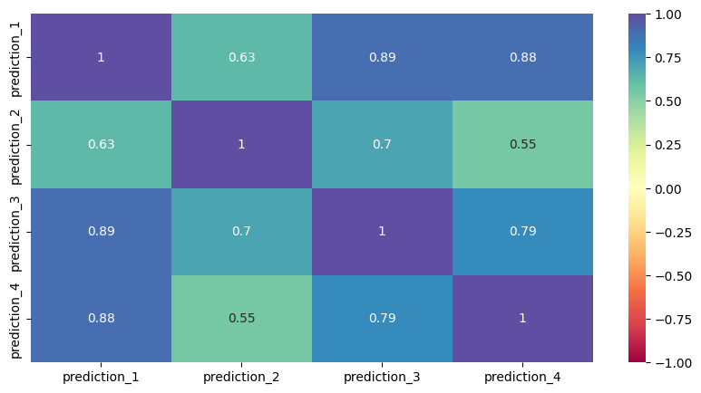

```python
# Show the correlation of the predictions
plt.figure(figsize=(10,5))
sns.heatmap(X_train.corr(),annot=True,cmap='Spectral',vmin=-1,vmax=1)
plt.show()
```

Use PCA to remove correlation before applying linear regression.

```python
# Handle correlation with PCA
pca = PCA(n_components=len(models))
X_train_pca = pca.fit_transform(X_train)
print("Explained variance ratio:", pca.explained_variance_ratio_)
print("Total explained variance:", np.sum(pca.explained_variance_ratio_))
X_test_pca = pca.transform(X_test)
```

```
Explained variance ratio: [0.78465057 0.1575251  0.04427512 0.01354921]
Total explained variance: 0.9999999999999998
```

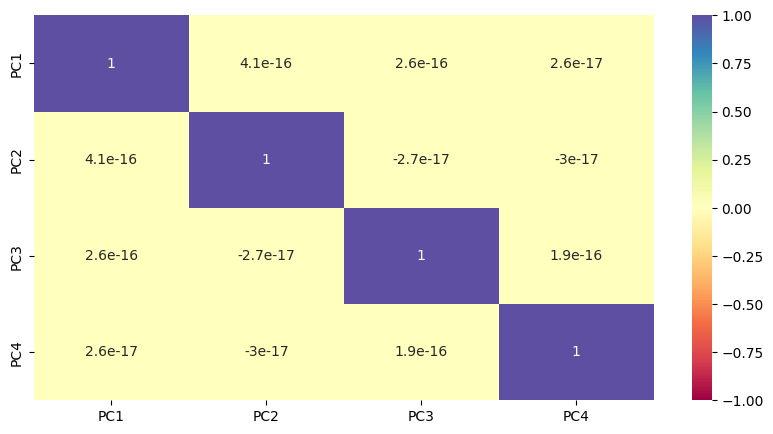

```python
# Convert PCA result to DataFrame
X_train_pca_df = pd.DataFrame(X_train_pca, columns=[f'PC{i+1}' for i in range(X_train_pca.shape[1])])
# Show the correlation after PCA
plt.figure(figsize=(10,5))
sns.heatmap(X_train_pca_df.corr(),annot=True,cmap='Spectral',vmin=-1,vmax=1)
plt.show()
```

After applying PCA, the resulting principal components are orthogonal to each other, effectively removing any correlations present in the original feature space.

#### Hybrid - Linear Regression recommendation system

```python
# Get predictions from models for the training set (recover from backup)
df_trainset_pred = df_trainset_pred_init

# Get predictions from models for the test set (recover from backup)
df_testset_pred = df_testset_pred_init

# Train a linear regression model using the PCA components
lr = LinearRegression()
lr.fit(X_train_pca, y_train)

df_trainset_pred = hybrid_process(X_train_pca, df_trainset_pred, lr)

# Predict play count using the hybrid model
print('---------------------------------------------------------------------------------------------------------')
print('Apply on Test Set:')
df_testset_pred = hybrid_process(X_test_pca, df_testset_pred, lr)
```

```
---------------------------------------------------------------------------------------------------------
Regression Mean Squared Error: 0.139
Regression Coefficients: [ 0.90024207  1.23354473 -0.25237379 -1.00126614]
Regression Intercept   : 1.698960763520679
---------------------------------------------------------------------------------------------------------
Apply on Test Set:
---------------------------------------------------------------------------------------------------------
Regression Mean Squared Error: 1.151
Regression Coefficients: [ 0.90024207  1.23354473 -0.25237379 -1.00126614]
Regression Intercept   : 1.698960763520679
```

```python
# Calc precision@k, recall@k, and F_1 score
precision, recall, f1, rmse = hybrid_precision_recall_at_k(df_testset_pred, k=30, threshold=1.5)

# Save the model's info
Hybrid_params = lr.get_params()
add_model_record(df_model_info, 'Hybrid - PCA and Linear Regression', Hybrid_params, precision, recall, f1, rmse, model_combination)
```

```
---------------------------------------------------------------------------------------------------------
RMSE:  1.07291722
Precision:  0.38700885
Recall:  0.81904644
F_1 score:  0.52564459
---------------------------------------------------------------------------------------------------------
```

The Recall score has improved greatly! It increased to 0.819! Let's look into the detailed predictions for both train set and test set.

```python
df_trainset_pred
```

|  | user_id | song_id | actual | prediction_1 | prediction_2 | prediction_3 | prediction_4 | hybrid_prediction |
| --- | --- | --- | --- | --- | --- | --- | --- | --- |
| 0 | 64559 | 211 | 2.0 | 1.785743 | 1.393348 | 1.730729 | 1.414002 | 1.623801 |
| 1 | 64559 | 6089 | 1.0 | 1.573300 | 1.178378 | 1.559445 | 1.362018 | 1.331303 |
| 2 | 64559 | 605 | 3.0 | 1.951711 | 2.531376 | 2.023869 | 2.079181 | 3.335594 |
| 3 | 64559 | 8814 | 1.0 | 1.748028 | 1.180857 | 1.748364 | 2.389443 | 1.324660 |
| 4 | 64559 | 617 | 2.0 | 1.813694 | 1.475221 | 1.748459 | 1.748736 | 1.718527 |
| ... | ... | ... | ... | ... | ... | ... | ... | ... |
| 70720 | 19776 | 6572 | 3.0 | 2.103769 | 2.388626 | 1.698961 | 2.927391 | 2.684862 |
| 70721 | 73609 | 7321 | 5.0 | 3.098336 | 3.872915 | 1.698961 | 4.532017 | 3.940255 |
| 70722 | 73609 | 1828 | 4.0 | 3.040428 | 3.450704 | 1.698961 | 4.536102 | 3.389322 |
| 70723 | 58702 | 3207 | 1.0 | 1.486549 | 1.000000 | 1.698961 | 1.012195 | 1.288662 |
| 70724 | 45476 | 3356 | 1.0 | 1.351929 | 1.000000 | 1.698961 | 0.999792 | 1.392630 |

70725 rows × 8 columns

```python
df_testset_pred
```

|  | user_id | song_id | actual | prediction_1 | prediction_2 | prediction_3 | prediction_4 | hybrid_prediction |
| --- | --- | --- | --- | --- | --- | --- | --- | --- |
| 0 | 26071 | 7103 | 1.0 | 1.359248 | 1.580000 | 1.291395 | 1.418100 | 1.816814 |
| 1 | 51242 | 8224 | 1.0 | 1.430570 | 1.354362 | 1.490042 | 1.244506 | 1.631595 |
| 2 | 72299 | 473 | 1.0 | 1.490770 | 1.665748 | 1.698961 | 1.296785 | 2.210998 |
| 3 | 28196 | 1354 | 1.0 | 1.592781 | 1.711504 | 1.443687 | 1.477591 | 1.957916 |
| 4 | 63083 | 4949 | 1.0 | 1.463694 | 1.556297 | 1.970716 | 1.133955 | 2.330816 |
| ... | ... | ... | ... | ... | ... | ... | ... | ... |
| 47146 | 33827 | 1811 | 1.0 | 1.717006 | 1.767515 | 1.726400 | 1.377887 | 2.201822 |
| 47147 | 75787 | 9055 | 3.0 | 1.794417 | 1.403574 | 1.930936 | 1.812411 | 1.794535 |
| 47148 | 1136 | 4399 | 1.0 | 1.253208 | 1.331822 | 1.403101 | 1.454494 | 1.647803 |
| 47149 | 70318 | 8094 | 1.0 | 1.440387 | 1.506389 | 1.353571 | 1.029258 | 1.724715 |
| 47150 | 58127 | 3518 | 3.0 | 1.531401 | 1.944197 | 1.460285 | 2.111538 | 2.319205 |

47151 rows × 8 columns

```python
# Check predictions for a user with an interacted song
h_pred = hybrid_predict(models, 6958, 1671, lr, pca_model=pca)
```

```
    uid   iid  hybrid_prediction  prediction_1  prediction_2  prediction_3  prediction_4
0  6958  1671           1.786329       1.34324      1.532574      1.331966       1.69496
```

It looks pretty good. The PCA and Linear Regression predicted 1.8~ is very close the actual 2.0 play count.

```python
# Check predictions for a user with an not-interacted song
h_pred = hybrid_predict(models, 6958, 3232, lr, pca_model=pca)
```

```
    uid   iid  hybrid_prediction  prediction_1  prediction_2  prediction_3  prediction_4
0  6958  3232           1.700604      1.442548      1.440264      1.474644      1.879304
```

```python
# Making top 5 recommendations for a user_id with hybrid recommendation engine
hybrid_recommendations = hybrid_get_recommendations(df_final, 6958, 5, models, lr, pca_model=pca)

# Applying the ranking_songs function
ranking_songs(hybrid_recommendations, final_play)
```

|  | song_id | play_freq | predicted_play_count | corrected_play_count |
| --- | --- | --- | --- | --- |
| 4 | 6450 | 102 | [2.925711354215082] | [2.8266965999174145] |
| 2 | 6448 | 109 | [2.8525668703994667] | [2.7567842418773516] |
| 0 | 5531 | 618 | [2.6739206590642697] | [2.6336947597288134] |
| 3 | 8831 | 107 | [2.711241460039452] | [2.6145678111348856] |
| 1 | 9942 | 150 | [2.6743071600880466] | [2.592657501995274] |

**Observations and Insights:**

- We use PCA and Linear Regression to build a hybrid model based on the 4 optimized models.
- The Hybrid model improve the performance greatly! The recall score increased to **0.819**! And F1 scores have been increased too. Though Precision score decreased a bit, and RMSE increased a bit.
- We implement the prediction and recommendation function for the hybrid model.

#### Hybrid - Ridge Regression recommendation system

```python
# Get predictions from models for the training set (recover from backup)
df_trainset_pred = df_trainset_pred_init

# Get predictions from models for the test set (recover from backup)
df_testset_pred = df_testset_pred_init

# Train a Ridge regression model using the PCA components
ridge = Ridge()
ridge.fit(X_train, y_train)

df_trainset_pred = hybrid_process(X_train, df_trainset_pred, ridge)

# Predict play count using the hybrid model
print('---------------------------------------------------------------------------------------------------------')
print('Apply on Test Set:')
df_testset_pred = hybrid_process(X_test, df_testset_pred, ridge)
```

```
---------------------------------------------------------------------------------------------------------
Regression Mean Squared Error: 0.139
Regression Coefficients: [-0.76733083  1.40973453  0.90442117 -0.04579351]
Regression Intercept   : -0.4706719704943021
---------------------------------------------------------------------------------------------------------
Apply on Test Set:
---------------------------------------------------------------------------------------------------------
Regression Mean Squared Error: 1.151
Regression Coefficients: [-0.76733083  1.40973453  0.90442117 -0.04579351]
Regression Intercept   : -0.4706719704943021
```

```python
# Calc precision@k, recall@k, and F_1 score
precision, recall, f1, rmse = hybrid_precision_recall_at_k(df_testset_pred, k=30, threshold=1.5)

# Save the model's info
Hybrid_params = ridge.get_params()
add_model_record(df_model_info, 'Hybrid - Ridge Regression', Hybrid_params, precision, recall, f1, rmse, model_combination)
```

```
---------------------------------------------------------------------------------------------------------
RMSE:  1.07289488
Precision:  0.3870416
Recall:  0.81910619
F_1 score:  0.52568711
---------------------------------------------------------------------------------------------------------
```

Not much difference with the Linear Regression model. Let's try to tune it.

#### Improving Hybrid - Ridge Regression recommendation system by tuning its hyper-parameters

```python
#------------------------------------------------------------------------------------------------------------------------------------------
# Tune the Ridge Regression
#------------------------------------------------------------------------------------------------------------------------------------------
# Get predictions from models for the training set (recover from backup)
df_trainset_pred = df_trainset_pred_init

# Get predictions from models for the test set (recover from backup)
df_testset_pred = df_testset_pred_init

# Define Ridge regression model
ridge_optimized = Ridge()

# Define hyperparameters to tune
param_grid_ridge = {
    'alpha': [0.1, 1.0, 10.0, 100.0],
    'fit_intercept': [True, False],
    'max_iter': [None, 1000, 2000],
    'tol': [0.001, 0.0001],
    'solver': ['auto', 'svd', 'cholesky', 'lsqr', 'sparse_cg', 'sag', 'saga']
}

# Perform grid search with cross-validation
grid_search_ridge = SklearnGridSearchCV(ridge_optimized, param_grid_ridge, cv=5, scoring='neg_mean_squared_error')
grid_search_ridge.fit(X_train, y_train)

# Best estimator
print("Ridge regression - Best estimator :")
print(grid_search_ridge.best_estimator_)

# Best parameters
print("Ridge regression - Best parameters:")
print(grid_search_ridge.best_params_)

# Best score
print("Ridge regression - Best score     :")
print(grid_search_ridge.best_score_)

ridge_optimized = grid_search_ridge.best_estimator_

df_trainset_pred = hybrid_process(X_train, df_trainset_pred, ridge_optimized)

# Predict play count using the hybrid model
print('---------------------------------------------------------------------------------------------------------')
print('Apply on Test Set:')
df_testset_pred = hybrid_process(X_test, df_testset_pred, ridge_optimized)
```

```
Ridge regression - Best estimator :
Ridge(alpha=100.0, solver='sag', tol=0.001)
Ridge regression - Best parameters:
{'alpha': 100.0, 'fit_intercept': True, 'max_iter': None, 'solver': 'sag', 'tol': 0.001}
Ridge regression - Best score     :
-0.14289529555437633
---------------------------------------------------------------------------------------------------------
Regression Mean Squared Error: 0.14
Regression Coefficients: [-0.69725236  1.40493319  0.86561588 -0.06032902]
Regression Intercept   : -0.4945796280659418
---------------------------------------------------------------------------------------------------------
Apply on Test Set:
---------------------------------------------------------------------------------------------------------
Regression Mean Squared Error: 1.147
Regression Coefficients: [-0.69725236  1.40493319  0.86561588 -0.06032902]
Regression Intercept   : -0.4945796280659418
```

```python
# Calc precision@k, recall@k, and F_1 score
precision, recall, f1, rmse = hybrid_precision_recall_at_k(df_testset_pred, k=30, threshold=1.5)

# Save the model's info
#Hybrid_params = grid_search_ridge.best_params_
Hybrid_params = str({**grid_search_ridge.best_params_,**ridge_optimized.get_params()})
add_model_record(df_model_info, 'Hybrid - Ridge Regression Optimized', Hybrid_params, precision, recall, f1, rmse, model_combination)
```

```
---------------------------------------------------------------------------------------------------------
RMSE:  1.07081739
Precision:  0.38784069
Recall:  0.81857298
F_1 score:  0.52631351
---------------------------------------------------------------------------------------------------------
```

```python
# Check predictions for a user with an interacted song
h_pred = hybrid_predict(models, 6958, 1671, ridge_optimized)
```

```
    uid   iid  hybrid_prediction  prediction_1  prediction_2  prediction_3  prediction_4
0  6958  1671           1.772723       1.34324      1.532574      1.331966       1.69496
```

It looks pretty good. The Ridge model predicted 1.8~ is very close the actual 2.0 play count.

```python
# Check predictions for a user with an not-interacted song
h_pred = hybrid_predict(models, 6958, 3232, ridge_optimized)
```

```
    uid   iid  hybrid_prediction  prediction_1  prediction_2  prediction_3  prediction_4
0  6958  3232           1.686173      1.442548      1.440264      1.474644      1.879304
```

```python
# Making top 5 recommendations for a user_id with hybrid recommendation engine
hybrid_recommendations = hybrid_get_recommendations(df_final, 6958, 5, models, ridge_optimized)

# Applying the ranking_songs function
ranking_songs(hybrid_recommendations, final_play)
```

|  | song_id | play_freq | predicted_play_count | corrected_play_count |
| --- | --- | --- | --- | --- |
| 4 | 6450 | 102 | [2.9464785766415647] | [2.8474638223438973] |
| 2 | 6448 | 109 | [2.84620809567598] | [2.750425467153865] |
| 0 | 5531 | 618 | [2.682463444265946] | [2.64223754493049] |
| 3 | 8831 | 107 | [2.715701157846853] | [2.6190275089422865] |
| 1 | 9942 | 150 | [2.671900320907409] | [2.5902506628146362] |

**Observations and Insights:**

- The Ridge regression models return almost the same scores, not much difference with the linear regression ones. The Optimized one got a little bit higher F1 score and Precision score, and the lowest RMSE.

#### Hybrid - Lasso Regression recommendation system

```python
# Get predictions from models for the training set (recover from backup)
df_trainset_pred = df_trainset_pred_init

# Get predictions from models for the test set (recover from backup)
df_testset_pred = df_testset_pred_init

# Train a Lasso regression model using the PCA components
lasso = Lasso()
lasso.fit(X_train, y_train)

df_trainset_pred = hybrid_process(X_train, df_trainset_pred, lasso)

# Predict play count using the hybrid model
print('---------------------------------------------------------------------------------------------------------')
print('Apply on Test Set:')
df_testset_pred = hybrid_process(X_test, df_testset_pred, lasso)
```

```
---------------------------------------------------------------------------------------------------------
Regression Mean Squared Error: 1.187
Regression Coefficients: [0. 0. 0. 0.]
Regression Intercept   : 1.6989607635206787
---------------------------------------------------------------------------------------------------------
Apply on Test Set:
---------------------------------------------------------------------------------------------------------
Regression Mean Squared Error: 1.188
Regression Coefficients: [0. 0. 0. 0.]
Regression Intercept   : 1.6989607635206787
```

```python
# Calc precision@k, recall@k, and F_1 score
precision, recall, f1, rmse = hybrid_precision_recall_at_k(df_testset_pred, k=30, threshold=1.5)
```

```
---------------------------------------------------------------------------------------------------------
RMSE:  1.08974415
Precision:  0.38372842
Recall:  0.89320594
F_1 score:  0.53683026
---------------------------------------------------------------------------------------------------------
```

There is something werid in the Lasso regression. Let's check any Constant Predictor exist.

```python
# check if the column has the same value for all rows
constant_columns = [col for col in df_trainset_pred.columns if df_trainset_pred[col].nunique() == 1]
print("Constant columns:", constant_columns)
```

```
Constant columns: ['hybrid_prediction']
```

```python
df_trainset_pred
```

|  | user_id | song_id | actual | prediction_1 | prediction_2 | prediction_3 | prediction_4 | hybrid_prediction |
| --- | --- | --- | --- | --- | --- | --- | --- | --- |
| 0 | 64559 | 211 | 2.0 | 1.785743 | 1.393348 | 1.730729 | 1.414002 | 1.698961 |
| 1 | 64559 | 6089 | 1.0 | 1.573300 | 1.178378 | 1.559445 | 1.362018 | 1.698961 |
| 2 | 64559 | 605 | 3.0 | 1.951711 | 2.531376 | 2.023869 | 2.079181 | 1.698961 |
| 3 | 64559 | 8814 | 1.0 | 1.748028 | 1.180857 | 1.748364 | 2.389443 | 1.698961 |
| 4 | 64559 | 617 | 2.0 | 1.813694 | 1.475221 | 1.748459 | 1.748736 | 1.698961 |
| ... | ... | ... | ... | ... | ... | ... | ... | ... |
| 70720 | 19776 | 6572 | 3.0 | 2.103769 | 2.388626 | 1.698961 | 2.927391 | 1.698961 |
| 70721 | 73609 | 7321 | 5.0 | 3.098336 | 3.872915 | 1.698961 | 4.532017 | 1.698961 |
| 70722 | 73609 | 1828 | 4.0 | 3.040428 | 3.450704 | 1.698961 | 4.536102 | 1.698961 |
| 70723 | 58702 | 3207 | 1.0 | 1.486549 | 1.000000 | 1.698961 | 1.012195 | 1.698961 |
| 70724 | 45476 | 3356 | 1.0 | 1.351929 | 1.000000 | 1.698961 | 0.999792 | 1.698961 |

70725 rows × 8 columns

```python
df_testset_pred
```

|  | user_id | song_id | actual | prediction_1 | prediction_2 | prediction_3 | prediction_4 | hybrid_prediction |
| --- | --- | --- | --- | --- | --- | --- | --- | --- |
| 0 | 26071 | 7103 | 1.0 | 1.359248 | 1.580000 | 1.291395 | 1.418100 | 1.698961 |
| 1 | 51242 | 8224 | 1.0 | 1.430570 | 1.354362 | 1.490042 | 1.244506 | 1.698961 |
| 2 | 72299 | 473 | 1.0 | 1.490770 | 1.665748 | 1.698961 | 1.296785 | 1.698961 |
| 3 | 28196 | 1354 | 1.0 | 1.592781 | 1.711504 | 1.443687 | 1.477591 | 1.698961 |
| 4 | 63083 | 4949 | 1.0 | 1.463694 | 1.556297 | 1.970716 | 1.133955 | 1.698961 |
| ... | ... | ... | ... | ... | ... | ... | ... | ... |
| 47146 | 33827 | 1811 | 1.0 | 1.717006 | 1.767515 | 1.726400 | 1.377887 | 1.698961 |
| 47147 | 75787 | 9055 | 3.0 | 1.794417 | 1.403574 | 1.930936 | 1.812411 | 1.698961 |
| 47148 | 1136 | 4399 | 1.0 | 1.253208 | 1.331822 | 1.403101 | 1.454494 | 1.698961 |
| 47149 | 70318 | 8094 | 1.0 | 1.440387 | 1.506389 | 1.353571 | 1.029258 | 1.698961 |
| 47150 | 58127 | 3518 | 3.0 | 1.531401 | 1.944197 | 1.460285 | 2.111538 | 1.698961 |

47151 rows × 8 columns

```python
# Check the actual play count's mean
print(df_trainset_pred['actual'].mean())
print(df_testset_pred['actual'].mean())
```

```
1.6989607635206787
1.7017030391720218
```

Yes, the Lasso regression model is **overshrinking**, driving all feature coefficients to zero, it only predicts the mean of the target variable, becoming a constant predictor.

Let's try to tune it.

#### Improving Hybrid - Lasso Regression recommendation system by tuning its hyper-parameters

```python
#------------------------------------------------------------------------------------------------------------------------------------------
# Tune the Lasso Regression
#------------------------------------------------------------------------------------------------------------------------------------------
# Get predictions from models for the training set (recover from backup)
df_trainset_pred = df_trainset_pred_init

# Get predictions from models for the test set (recover from backup)
df_testset_pred = df_testset_pred_init

# Define lasso regression model
lasso_optimized = Lasso()

# Define hyperparameters to tune
param_grid_lasso = {
  'alpha': [0.01, 0.1, 1.0, 10.0, 100.0],    # Regularization strength for Lasso
  'max_iter': [1000, 2000, 3000],            # Maximum number of iterations
  'tol': [0.0001, 0.001, 0.01]               # Tolerance for stopping criteria
}

# Perform grid search with cross-validation
grid_search_lasso = SklearnGridSearchCV(lasso_optimized, param_grid_lasso, cv=5, scoring='neg_mean_squared_error')
grid_search_lasso.fit(X_train, y_train)

# Best estimator
print("Lasso regression - Best estimator :")
print(grid_search_lasso.best_estimator_)

# Best parameters
print("Lasso regression - Best parameters:")
print(grid_search_lasso.best_params_)

# Best score
print("Lasso regression - Best score     :")
print(grid_search_lasso.best_score_)

lasso_optimized = grid_search_lasso.best_estimator_

df_trainset_pred = hybrid_process(X_train, df_trainset_pred, lasso_optimized)

# Predict play count using the hybrid model
print('---------------------------------------------------------------------------------------------------------')
print('Apply on Test Set:')
df_testset_pred = hybrid_process(X_test, df_testset_pred, lasso_optimized)
```

```
Lasso regression - Best estimator :
Lasso(alpha=0.01, tol=0.01)
Lasso regression - Best parameters:
{'alpha': 0.01, 'max_iter': 1000, 'tol': 0.01}
Lasso regression - Best score     :
-0.15114913878344566
---------------------------------------------------------------------------------------------------------
Regression Mean Squared Error: 0.148
Regression Coefficients: [-0.22905904  1.39565674  0.53181657 -0.09844187]
Regression Intercept   : -0.6669619100865241
---------------------------------------------------------------------------------------------------------
Apply on Test Set:
---------------------------------------------------------------------------------------------------------
Regression Mean Squared Error: 1.123
Regression Coefficients: [-0.22905904  1.39565674  0.53181657 -0.09844187]
Regression Intercept   : -0.6669619100865241
```

```python
# Calc precision@k, recall@k, and F_1 score
precision, recall, f1, rmse = hybrid_precision_recall_at_k(df_testset_pred, k=30, threshold=1.5)

# Save the model's info
#Hybrid_params = grid_search_lasso.best_params_
Hybrid_params = str({**grid_search_lasso.best_params_,**lasso_optimized.get_params()})
add_model_record(df_model_info, 'Hybrid - Lasso Regression Optimized', Hybrid_params, precision, recall, f1, rmse, model_combination)
```

```
---------------------------------------------------------------------------------------------------------
RMSE:  1.05963662
Precision:  0.39367326
Recall:  0.80752762
F_1 score:  0.52930702
---------------------------------------------------------------------------------------------------------
```

```python
# check if the column has the same value for all rows
constant_columns = [col for col in df_trainset_pred.columns if df_trainset_pred[col].nunique() == 1]
print("Constant columns:", constant_columns)
```

```
Constant columns: []
```

The tuning solved the shrinking problem. Let's try the prediction and recommendation function too.

```python
# Check predictions for a user with an interacted song
h_pred = hybrid_predict(models, 6958, 1671, lasso_optimized)
```

```
    uid   iid  hybrid_prediction  prediction_1  prediction_2  prediction_3  prediction_4
0  6958  1671           1.705811       1.34324      1.532574      1.331966       1.69496
```

It looks pretty good. The Lasso model predicted 1.7~ is very close the actual 2.0 play count.

```python
# Check predictions for a user with an not-interacted song
h_pred = hybrid_predict(models, 6958, 3232, lasso_optimized)
```

```
    uid   iid  hybrid_prediction  prediction_1  prediction_2  prediction_3  prediction_4
0  6958  3232           1.611961      1.442548      1.440264      1.474644      1.879304
```

```python
# Making top 5 recommendations for a user_id with hybrid recommendation engine
hybrid_recommendations = hybrid_get_recommendations(df_final, 6958, 5, models, lasso_optimized)

# Applying the ranking_songs function
ranking_songs(hybrid_recommendations, final_play)
```

|  | song_id | play_freq | predicted_play_count | corrected_play_count |
| --- | --- | --- | --- | --- |
| 4 | 6450 | 102 | [3.142197369882307] | [3.0431826155846395] |
| 2 | 7224 | 107 | [3.1373690063122304] | [3.040695357407664] |
| 1 | 6448 | 109 | [2.8589618710335154] | [2.7631792425114003] |
| 0 | 5531 | 618 | [2.7778578840956496] | [2.7376319847601933] |
| 3 | 8831 | 107 | [2.760309520265543] | [2.6636358713609765] |

**Observations and Insights:**

#### Hybrid - combine SVD and User-User only

As SVD and User-User model has higher precision score, let's combine these two to to see if there is any improvement.

```python
# Combine 2 models only
models = [svd_optimized, sim_user_user_optimized]
model_combination = 'SVD, U-U'

X_train, y_train, df_trainset_pred = hybrid_extract(models, trainset_tuples)
# Create a deep copy to backup the init. value
df_trainset_pred_init = df_trainset_pred.copy(deep=True)

# Get predictions from models for the test set
X_test, y_test, df_testset_pred = hybrid_extract(models, testset)
# Create a deep copy to backup the init. value
df_testset_pred_init = df_testset_pred.copy(deep=True)
```

```python
# Handle correlation with PCA
pca = PCA(n_components=len(models))
X_train_pca = pca.fit_transform(X_train)
print("Explained variance ratio:", pca.explained_variance_ratio_)
print("Total explained variance:", np.sum(pca.explained_variance_ratio_))
X_test_pca = pca.transform(X_test)
```

```
Explained variance ratio: [0.85221686 0.14778314]
Total explained variance: 1.0
```

```python
# Get predictions from models for the training set (recover from backup)
df_trainset_pred = df_trainset_pred_init

# Get predictions from models for the test set (recover from backup)
df_testset_pred = df_testset_pred_init

# Train a linear regression model using the PCA components
lr = LinearRegression()
lr.fit(X_train_pca, y_train)

df_trainset_pred = hybrid_process(X_train_pca, df_trainset_pred, lr)

# Predict play count using the hybrid model
print('---------------------------------------------------------------------------------------------------------')
print('Apply on Test Set:')
df_testset_pred = hybrid_process(X_test_pca, df_testset_pred, lr)
```

```
---------------------------------------------------------------------------------------------------------
Regression Mean Squared Error: 0.176
Regression Coefficients: [ 1.38372752 -0.74504358]
Regression Intercept   : 1.698960763520679
---------------------------------------------------------------------------------------------------------
Apply on Test Set:
---------------------------------------------------------------------------------------------------------
Regression Mean Squared Error: 1.17
Regression Coefficients: [ 1.38372752 -0.74504358]
Regression Intercept   : 1.698960763520679
```

```python
# Calc precision@k, recall@k, and F_1 score
precision, recall, f1, rmse = hybrid_precision_recall_at_k(df_testset_pred, k=30, threshold=1.5)

# Save the model's info
Hybrid_params = lr.get_params()
add_model_record(df_model_info, 'Hybrid - PCA and Linear Regression', Hybrid_params, precision, recall, f1, rmse, model_combination)
```

```
---------------------------------------------------------------------------------------------------------
RMSE:  1.08180455
Precision:  0.39718995
Recall:  0.79836766
F_1 score:  0.53046981
---------------------------------------------------------------------------------------------------------
```

```python
#------------------------------------------------------------------------------------------------------------------------------------------
# Tune the Ridge Regression
#------------------------------------------------------------------------------------------------------------------------------------------
# Get predictions from models for the training set (recover from backup)
df_trainset_pred = df_trainset_pred_init

# Get predictions from models for the test set (recover from backup)
df_testset_pred = df_testset_pred_init

# Define Ridge regression model
ridge_optimized = Ridge()

# Define hyperparameters to tune
param_grid_ridge = {
    'alpha': [0.1, 1.0, 10.0, 100.0],
    'fit_intercept': [True, False],
    'max_iter': [None, 1000, 2000],
    'tol': [0.001, 0.0001],
    'solver': ['auto', 'svd', 'cholesky', 'lsqr', 'sparse_cg', 'sag', 'saga']
}

# Perform grid search with cross-validation
grid_search_ridge = SklearnGridSearchCV(ridge_optimized, param_grid_ridge, cv=5, scoring='neg_mean_squared_error')
grid_search_ridge.fit(X_train, y_train)

# Best estimator
print("Ridge regression - Best estimator :")
print(grid_search_ridge.best_estimator_)

# Best parameters
print("Ridge regression - Best parameters:")
print(grid_search_ridge.best_params_)

# Best score
print("Ridge regression - Best score     :")
print(grid_search_ridge.best_score_)

ridge_optimized = grid_search_ridge.best_estimator_

df_trainset_pred = hybrid_process(X_train, df_trainset_pred, ridge_optimized)

# Predict play count using the hybrid model
print('---------------------------------------------------------------------------------------------------------')
print('Apply on Test Set:')
df_testset_pred = hybrid_process(X_test, df_testset_pred, ridge_optimized)
```

```
Ridge regression - Best estimator :
Ridge(alpha=100.0, solver='sag', tol=0.001)
Ridge regression - Best parameters:
{'alpha': 100.0, 'fit_intercept': True, 'max_iter': None, 'solver': 'sag', 'tol': 0.001}
Ridge regression - Best score     :
-0.17811287434856743
---------------------------------------------------------------------------------------------------------
Regression Mean Squared Error: 0.176
Regression Coefficients: [-0.01106607  1.56271874]
Regression Intercept   : -0.5852753415301719
---------------------------------------------------------------------------------------------------------
Apply on Test Set:
---------------------------------------------------------------------------------------------------------
Regression Mean Squared Error: 1.168
Regression Coefficients: [-0.01106607  1.56271874]
Regression Intercept   : -0.5852753415301719
```

```python
# Calc precision@k, recall@k, and F_1 score
precision, recall, f1, rmse = hybrid_precision_recall_at_k(df_testset_pred, k=30, threshold=1.5)

# Save the model's info
#Hybrid_params = grid_search_ridge.best_params_
Hybrid_params = str({**grid_search_ridge.best_params_,**ridge_optimized.get_params()})
add_model_record(df_model_info, 'Hybrid - Ridge Regression Optimized', Hybrid_params, precision, recall, f1, rmse, model_combination)
```

```
---------------------------------------------------------------------------------------------------------
RMSE:  1.08084998
Precision:  0.3972869
Recall:  0.7985075
F_1 score:  0.53058715
---------------------------------------------------------------------------------------------------------
```

```python
#------------------------------------------------------------------------------------------------------------------------------------------
# Tune the Lasso Regression
#------------------------------------------------------------------------------------------------------------------------------------------
# Get predictions from models for the training set (recover from backup)
df_trainset_pred = df_trainset_pred_init

# Get predictions from models for the test set (recover from backup)
df_testset_pred = df_testset_pred_init

# Define lasso regression model
lasso_optimized = Lasso()

# Define hyperparameters to tune
param_grid_lasso = {
  'alpha': [0.01, 0.1, 1.0, 10.0, 100.0],    # Regularization strength for Lasso
  'max_iter': [1000, 2000, 3000],            # Maximum number of iterations
  'tol': [0.0001, 0.001, 0.01]               # Tolerance for stopping criteria
}

# Perform grid search with cross-validation
grid_search_lasso = SklearnGridSearchCV(lasso_optimized, param_grid_lasso, cv=5, scoring='neg_mean_squared_error')
grid_search_lasso.fit(X_train, y_train)

# Best estimator
print("Lasso regression - Best estimator :")
print(grid_search_lasso.best_estimator_)

# Best parameters
print("Lasso regression - Best parameters:")
print(grid_search_lasso.best_params_)

# Best score
print("Lasso regression - Best score     :")
print(grid_search_lasso.best_score_)

lasso_optimized = grid_search_lasso.best_estimator_

df_trainset_pred = hybrid_process(X_train, df_trainset_pred, lasso_optimized)

# Predict play count using the hybrid model
print('---------------------------------------------------------------------------------------------------------')
print('Apply on Test Set:')
df_testset_pred = hybrid_process(X_test, df_testset_pred, lasso_optimized)
```

```
Lasso regression - Best estimator :
Lasso(alpha=0.01)
Lasso regression - Best parameters:
{'alpha': 0.01, 'max_iter': 1000, 'tol': 0.0001}
Lasso regression - Best score     :
-0.17817050310422272
---------------------------------------------------------------------------------------------------------
Regression Mean Squared Error: 0.176
Regression Coefficients: [0.         1.53960674]
Regression Intercept   : -0.5699690348054802
---------------------------------------------------------------------------------------------------------
Apply on Test Set:
---------------------------------------------------------------------------------------------------------
Regression Mean Squared Error: 1.164
Regression Coefficients: [0.         1.53960674]
Regression Intercept   : -0.5699690348054802
```

```python
# Calc precision@k, recall@k, and F_1 score
precision, recall, f1, rmse = hybrid_precision_recall_at_k(df_testset_pred, k=30, threshold=1.5)

# Save the model's info
#Hybrid_params = grid_search_lasso.best_params_
Hybrid_params = str({**grid_search_lasso.best_params_,**lasso_optimized.get_params()})
add_model_record(df_model_info, 'Hybrid - Lasso Regression Optimized', Hybrid_params, precision, recall, f1, rmse, model_combination)
```

```
---------------------------------------------------------------------------------------------------------
RMSE:  1.07889889
Precision:  0.39691628
Recall:  0.79952749
F_1 score:  0.53048122
---------------------------------------------------------------------------------------------------------
```

```python
# check if the column has the same value for all rows
constant_columns = [col for col in df_trainset_pred.columns if df_trainset_pred[col].nunique() == 1]
print("Constant columns:", constant_columns)
```

```
Constant columns: []
```

```python
# Check predictions for a user with an interacted song
h_pred = hybrid_predict(models, 6958, 1671, lasso_optimized)
```

```
    uid   iid  hybrid_prediction  prediction_1  prediction_2
0  6958  1671           1.789592       1.34324      1.532574
```

It looks pretty good. The Lasso model predicted 1.7~ is very close the actual 2.0 play count.

```python
# Check predictions for a user with an not-interacted song
h_pred = hybrid_predict(models, 6958, 3232, lasso_optimized)
```

```
    uid   iid  hybrid_prediction  prediction_1  prediction_2
0  6958  3232           1.647471      1.442548      1.440264
```

```python
# Making top 5 recommendations for a user_id with hybrid recommendation engine
hybrid_recommendations = hybrid_get_recommendations(df_final, 6958, 5, models, lasso_optimized)

# Applying the ranking_songs function
ranking_songs(hybrid_recommendations, final_play)
```

|  | song_id | play_freq | predicted_play_count | corrected_play_count |
| --- | --- | --- | --- | --- |
| 1 | 7224 | 107 | [3.9491392697610777] | [3.852465620856511] |
| 2 | 6450 | 102 | [3.538809925807555] | [3.439795171509888] |
| 4 | 8324 | 96 | [3.2285562405447688] | [3.126494167928803] |
| 0 | 6448 | 109 | [3.1036594775977155] | [3.0078768490756005] |
| 3 | 4831 | 97 | [3.046350034067218] | [2.944815417553856] |

**Observations and Insights:**

- The precision score has **increased to ~0.397**. The F1 score has increased to **~0.53**.

#### Hybrid - combine User-User and Item-item only

As User-User and Item-item model complement each other, let's combine these two to see if there is any improvement.

```python
# Combine 2 models only
models = [sim_user_user_optimized, sim_item_item_optimized]
model_combination = 'U-U, I-I'

X_train, y_train, df_trainset_pred = hybrid_extract(models, trainset_tuples)
# Create a deep copy to backup the init. value
df_trainset_pred_init = df_trainset_pred.copy(deep=True)

# Get predictions from models for the test set
X_test, y_test, df_testset_pred = hybrid_extract(models, testset)
# Create a deep copy to backup the init. value
df_testset_pred_init = df_testset_pred.copy(deep=True)
```

```python
# Handle correlation with PCA
pca = PCA(n_components=len(models))
X_train_pca = pca.fit_transform(X_train)
print("Explained variance ratio:", pca.explained_variance_ratio_)
print("Total explained variance:", np.sum(pca.explained_variance_ratio_))
X_test_pca = pca.transform(X_test)
```

```
Explained variance ratio: [0.86073938 0.13926062]
Total explained variance: 1.0
```

```python
# Get predictions from models for the training set (recover from backup)
df_trainset_pred = df_trainset_pred_init

# Get predictions from models for the test set (recover from backup)
df_testset_pred = df_testset_pred_init

# Train a linear regression model using the PCA components
lr = LinearRegression()
lr.fit(X_train_pca, y_train)

df_trainset_pred = hybrid_process(X_train_pca, df_trainset_pred, lr)

# Predict play count using the hybrid model
print('---------------------------------------------------------------------------------------------------------')
print('Apply on Test Set:')
df_testset_pred = hybrid_process(X_test_pca, df_testset_pred, lr)
```

```
---------------------------------------------------------------------------------------------------------
Regression Mean Squared Error: 0.164
Regression Coefficients: [1.31753621 0.56275879]
Regression Intercept   : 1.698960763520679
---------------------------------------------------------------------------------------------------------
Apply on Test Set:
---------------------------------------------------------------------------------------------------------
Regression Mean Squared Error: 1.113
Regression Coefficients: [1.31753621 0.56275879]
Regression Intercept   : 1.698960763520679
```

```python
# Calc precision@k, recall@k, and F_1 score
precision, recall, f1, rmse = hybrid_precision_recall_at_k(df_testset_pred, k=30, threshold=1.5)

# Save the model's info
Hybrid_params = lr.get_params()
add_model_record(df_model_info, 'Hybrid - PCA and Linear Regression', Hybrid_params, precision, recall, f1, rmse, model_combination)
```

```
---------------------------------------------------------------------------------------------------------
RMSE:  1.05490706
Precision:  0.40061047
Recall:  0.78426938
F_1 score:  0.53032639
---------------------------------------------------------------------------------------------------------
```

```python
#------------------------------------------------------------------------------------------------------------------------------------------
# Tune the Ridge Regression
#------------------------------------------------------------------------------------------------------------------------------------------
# Get predictions from models for the training set (recover from backup)
df_trainset_pred = df_trainset_pred_init

# Get predictions from models for the test set (recover from backup)
df_testset_pred = df_testset_pred_init

# Define Ridge regression model
ridge_optimized = Ridge()

# Define hyperparameters to tune
param_grid_ridge = {
    'alpha': [0.1, 1.0, 10.0, 100.0],
    'fit_intercept': [True, False],
    'max_iter': [None, 1000, 2000],
    'tol': [0.001, 0.0001],
    'solver': ['auto', 'svd', 'cholesky', 'lsqr', 'sparse_cg', 'sag', 'saga']
}

# Perform grid search with cross-validation
grid_search_ridge = SklearnGridSearchCV(ridge_optimized, param_grid_ridge, cv=5, scoring='neg_mean_squared_error')
grid_search_ridge.fit(X_train, y_train)

# Best estimator
print("Ridge regression - Best estimator :")
print(grid_search_ridge.best_estimator_)

# Best parameters
print("Ridge regression - Best parameters:")
print(grid_search_ridge.best_params_)

# Best score
print("Ridge regression - Best score     :")
print(grid_search_ridge.best_score_)

ridge_optimized = grid_search_ridge.best_estimator_

df_trainset_pred = hybrid_process(X_train, df_trainset_pred, ridge_optimized)

# Predict play count using the hybrid model
print('---------------------------------------------------------------------------------------------------------')
print('Apply on Test Set:')
df_testset_pred = hybrid_process(X_test, df_testset_pred, ridge_optimized)
```

```
Ridge regression - Best estimator :
Ridge(alpha=0.1, max_iter=1000, solver='sag', tol=0.001)
Ridge regression - Best parameters:
{'alpha': 0.1, 'fit_intercept': True, 'max_iter': 1000, 'solver': 'sag', 'tol': 0.001}
Ridge regression - Best score     :
-0.16663858878405874
---------------------------------------------------------------------------------------------------------
Regression Mean Squared Error: 0.164
Regression Coefficients: [1.40217072 0.29706405]
Regression Intercept   : -0.8503655312328386
---------------------------------------------------------------------------------------------------------
Apply on Test Set:
---------------------------------------------------------------------------------------------------------
Regression Mean Squared Error: 1.113
Regression Coefficients: [1.40217072 0.29706405]
Regression Intercept   : -0.8503655312328386
```

```python
# Calc precision@k, recall@k, and F_1 score
precision, recall, f1, rmse = hybrid_precision_recall_at_k(df_testset_pred, k=30, threshold=1.5)

# Save the model's info
#Hybrid_params = grid_search_ridge.best_params_
Hybrid_params = str({**grid_search_ridge.best_params_,**ridge_optimized.get_params()})
add_model_record(df_model_info, 'Hybrid - Ridge Regression Optimized', Hybrid_params, precision, recall, f1, rmse, model_combination)
```

```
---------------------------------------------------------------------------------------------------------
RMSE:  1.05495792
Precision:  0.40060872
Recall:  0.78426938
F_1 score:  0.53032485
---------------------------------------------------------------------------------------------------------
```

```python
#------------------------------------------------------------------------------------------------------------------------------------------
# Tune the Lasso Regression
#------------------------------------------------------------------------------------------------------------------------------------------
# Get predictions from models for the training set (recover from backup)
df_trainset_pred = df_trainset_pred_init

# Get predictions from models for the test set (recover from backup)
df_testset_pred = df_testset_pred_init

# Define lasso regression model
lasso_optimized = Lasso()

# Define hyperparameters to tune
param_grid_lasso = {
  'alpha': [0.01, 0.1, 1.0, 10.0, 100.0],    # Regularization strength for Lasso
  'max_iter': [1000, 2000, 3000],            # Maximum number of iterations
  'tol': [0.0001, 0.001, 0.01]               # Tolerance for stopping criteria
}

# Perform grid search with cross-validation
grid_search_lasso = SklearnGridSearchCV(lasso_optimized, param_grid_lasso, cv=5, scoring='neg_mean_squared_error')
grid_search_lasso.fit(X_train, y_train)

# Best estimator
print("Lasso regression - Best estimator :")
print(grid_search_lasso.best_estimator_)

# Best parameters
print("Lasso regression - Best parameters:")
print(grid_search_lasso.best_params_)

# Best score
print("Lasso regression - Best score     :")
print(grid_search_lasso.best_score_)

lasso_optimized = grid_search_lasso.best_estimator_

df_trainset_pred = hybrid_process(X_train, df_trainset_pred, lasso_optimized)

# Predict play count using the hybrid model
print('---------------------------------------------------------------------------------------------------------')
print('Apply on Test Set:')
df_testset_pred = hybrid_process(X_test, df_testset_pred, lasso_optimized)
```

```
Lasso regression - Best estimator :
Lasso(alpha=0.01)
Lasso regression - Best parameters:
{'alpha': 0.01, 'max_iter': 1000, 'tol': 0.0001}
Lasso regression - Best score     :
-0.16704339758784603
---------------------------------------------------------------------------------------------------------
Regression Mean Squared Error: 0.165
Regression Coefficients: [1.39675453 0.26188017]
Regression Intercept   : -0.7851852436083986
---------------------------------------------------------------------------------------------------------
Apply on Test Set:
---------------------------------------------------------------------------------------------------------
Regression Mean Squared Error: 1.115
Regression Coefficients: [1.39675453 0.26188017]
Regression Intercept   : -0.7851852436083986
```

```python
# Calc precision@k, recall@k, and F_1 score
precision, recall, f1, rmse = hybrid_precision_recall_at_k(df_testset_pred, k=30, threshold=1.5)

# Save the model's info
#Hybrid_params = grid_search_lasso.best_params_
Hybrid_params = str({**grid_search_lasso.best_params_,**lasso_optimized.get_params()})
add_model_record(df_model_info, 'Hybrid - Lasso Regression Optimized', Hybrid_params, precision, recall, f1, rmse, model_combination)
```

```
---------------------------------------------------------------------------------------------------------
RMSE:  1.05582317
Precision:  0.3995207
Recall:  0.78901466
F_1 score:  0.5304473
---------------------------------------------------------------------------------------------------------
```

```python
# check if the column has the same value for all rows
constant_columns = [col for col in df_trainset_pred.columns if df_trainset_pred[col].nunique() == 1]
print("Constant columns:", constant_columns)
```

```
Constant columns: []
```

```python
# Check predictions for a user with an interacted song
h_pred = hybrid_predict(models, 6958, 1671, lasso_optimized)
```

```
    uid   iid  hybrid_prediction  prediction_1  prediction_2
0  6958  1671            1.70426      1.532574      1.331966
```

It looks pretty good. The Lasso model predicted 1.7~ is very close the actual 2.0 play count.

```python
# Check predictions for a user with an not-interacted song
h_pred = hybrid_predict(models, 6958, 3232, lasso_optimized)
```

```
    uid   iid  hybrid_prediction  prediction_1  prediction_2
0  6958  3232            1.61269      1.440264      1.474644
```

```python
# Making top 5 recommendations for a user_id with hybrid recommendation engine
hybrid_recommendations = hybrid_get_recommendations(df_final, 6958, 5, models, lasso_optimized)

# Applying the ranking_songs function
ranking_songs(hybrid_recommendations, final_play)
```

|  | song_id | play_freq | predicted_play_count | corrected_play_count |
| --- | --- | --- | --- | --- |
| 1 | 7224 | 107 | [3.5909094516497406] | [3.494235802745174] |
| 2 | 6450 | 102 | [3.295209612503869] | [3.1961948582062014] |
| 4 | 8324 | 96 | [3.0024945780183705] | [2.9004325054024047] |
| 0 | 6448 | 109 | [2.931096186038278] | [2.8353135575161628] |
| 3 | 4831 | 97 | [2.8823808307592826] | [2.780846214245921] |

**Observations and Insights:**

- The precision score has **increased to ~0.400**. F1 score is **~0.53**.

Let's build a recommendation system based on four basic optimized models. The main idea is to prioritize songs that are recommended more frequently, giving them a higher rank.

```python
def get_recommendations_forest(data, final_play, user_id, top_n, models):

    # Initialize an empty list to hold all DataFrames
    all_ranked_songs = []

    for model_index, model in enumerate(models):
        recommendations = get_recommendations(data, user_id, top_n, model)
        ranked_songs = ranking_songs(recommendations, final_play)

        #df_ranked_songs = pd.DataFrame(ranked_songs)
        # Add the model and user_id information
        ranked_songs['model'] = f'model_{model_index + 1}'
        ranked_songs['uid'] = user_id

        # Append the DataFrame to the list
        all_ranked_songs.append(ranked_songs)

    # Concatenate all DataFrames in the list into a single DataFrame
    df_ranked_songs = pd.concat(all_ranked_songs, ignore_index=True)

    # reset the index
    df_ranked_songs.reset_index(drop=True, inplace=True)

    # Group by 'song_id' and calculate the mean of 'play_count' and value counts
    df_ranked_songs_count = df_ranked_songs.groupby('song_id').agg(
        mean_play_count=('corrected_play_count', 'mean'),
        value_count=('song_id', 'size')
    ).reset_index()

    # Sort by 'value_count' in descending order, mean_play_count in descending order
    df_ranked_songs_count_sorted = df_ranked_songs_count.sort_values(by=['value_count', 'mean_play_count'], ascending=[False, False]).reset_index()

    return df_ranked_songs_count_sorted[:top_n] # Returing top n songs for this user
```

```python
models = [svd_optimized, sim_user_user_optimized, sim_item_item_optimized, clust_tuned]
forest_recommendations = get_recommendations_forest(df_final, final_play, 6958, 5, models)
print(forest_recommendations)
```

```
   index  song_id  mean_play_count  value_count
0      9     7224         2.620428            3
1     10     8324         2.295795            3
2      3     4831         2.335175            2
3      8     6450         2.211591            2
4     12     9942         1.912517            2
```

**Observations and Insights:**

- We implement a function to Make top n recommendations for any user id based on four basic optimized models. The final ranking will first be sorted by the number of recommendations in descending order and then by the average play count prediction in descending order. It will return the song ids and aver. predicted play counts.
- The function inherently uses the corrected play count, applying fewer penalties to frequently played songs and more penalties to less frequently played songs.

#### Comparing all the models

```python
# Check the model info dataframe
df_model_info
```

|  | Model Type | Parameters | Precision | Recall | F1 | RMSE | Combination |
| --- | --- | --- | --- | --- | --- | --- | --- |
| 0 | User-User | k=40, min_k=1, sim_options={'name': 'cosine', ... | 0.396197 | 0.691995 | 0.503894 | 1.087823 |  |
| 1 | User-User Optimized | k=50, min_k=9, sim_options={'name': 'msd', 'us... | 0.414300 | 0.623366 | 0.497772 | 1.059632 |  |
| 2 | Item-Item | k=40, min_k=1, sim_options={'name': 'cosine', ... | 0.306800 | 0.561836 | 0.396878 | 1.039363 |  |
| 3 | Item-Item Optimized | k=40, min_k=6, sim_options={'name': 'msd', 'us... | 0.336465 | 0.565642 | 0.421943 | 1.041560 |  |
| 4 | SVD | 'n_epochs':20, 'lr':0.005, 'reg':0.02 | 0.409666 | 0.633127 | 0.497454 | 1.025249 |  |
| 5 | SVD Optimized | {'rmse': {'n_epochs': 30, 'lr_all': 0.01, 'reg... | 0.414502 | 0.634777 | 0.501519 | 1.014134 |  |
| 6 | Cluster Based | n_cltr_u: 3, n_cltr_i: 3, n_epochs: 20 | 0.396558 | 0.582039 | 0.471721 | 1.048667 |  |
| 7 | Cluster Tuned | {'rmse': {'n_cltr_u': 3, 'n_cltr_i': 3, 'n_epo... | 0.392029 | 0.571986 | 0.465211 | 1.056770 |  |
| 8 | Hybrid - PCA and Linear Regression | {'copy_X': True, 'fit_intercept': True, 'n_job... | 0.387009 | 0.819046 | 0.525645 | 1.072917 | SVD, U-U, I-I, Co-Clustering |
| 9 | Hybrid - Ridge Regression | {'alpha': 1.0, 'copy_X': True, 'fit_intercept'... | 0.387042 | 0.819106 | 0.525687 | 1.072895 | SVD, U-U, I-I, Co-Clustering |
| 10 | Hybrid - Ridge Regression Optimized | {'alpha': 100.0, 'fit_intercept': True, 'max_i... | 0.387841 | 0.818573 | 0.526314 | 1.070817 | SVD, U-U, I-I, Co-Clustering |
| 11 | Hybrid - Lasso Regression Optimized | {'alpha': 0.01, 'max_iter': 1000, 'tol': 0.01,... | 0.393673 | 0.807528 | 0.529307 | 1.059637 | SVD, U-U, I-I, Co-Clustering |
| 12 | Hybrid - PCA and Linear Regression | {'copy_X': True, 'fit_intercept': True, 'n_job... | 0.397190 | 0.798368 | 0.530470 | 1.081805 | SVD, U-U |
| 13 | Hybrid - Ridge Regression Optimized | {'alpha': 100.0, 'fit_intercept': True, 'max_i... | 0.397287 | 0.798508 | 0.530587 | 1.080850 | SVD, U-U |
| 14 | Hybrid - Lasso Regression Optimized | {'alpha': 0.01, 'max_iter': 1000, 'tol': 0.000... | 0.396916 | 0.799527 | 0.530481 | 1.078899 | SVD, U-U |
| 15 | Hybrid - PCA and Linear Regression | {'copy_X': True, 'fit_intercept': True, 'n_job... | 0.400610 | 0.784269 | 0.530326 | 1.054907 | U-U, I-I |
| 16 | Hybrid - Ridge Regression Optimized | {'alpha': 0.1, 'fit_intercept': True, 'max_ite... | 0.400609 | 0.784269 | 0.530325 | 1.054958 | U-U, I-I |
| 17 | Hybrid - Lasso Regression Optimized | {'alpha': 0.01, 'max_iter': 1000, 'tol': 0.000... | 0.399521 | 0.789015 | 0.530447 | 1.055823 | U-U, I-I |

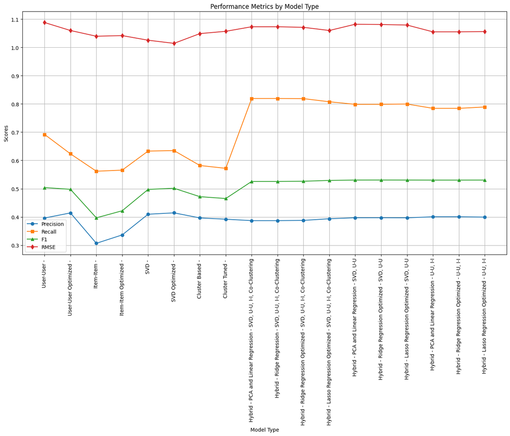

```python
# Combine 'Model Type' and 'Combination' into a new 'Display Model Type' column
df_model_info['Display Model Type'] = df_model_info['Model Type'] + " - " + df_model_info['Combination']

# Set the 'Display Model Type' column as the index for plotting
df_model_info.set_index('Display Model Type', inplace=True)

# Plot the line plot for each metric in the same chart
plt.figure(figsize=(14, 12))

plt.plot(df_model_info.index, df_model_info['Precision'], marker='o', label='Precision')
plt.plot(df_model_info.index, df_model_info['Recall'], marker='s', label='Recall')
plt.plot(df_model_info.index, df_model_info['F1'], marker='^', label='F1')
plt.plot(df_model_info.index, df_model_info['RMSE'], marker='d', label='RMSE')

plt.title('Performance Metrics by Model Type')
plt.xlabel('Model Type')
plt.ylabel('Scores')
plt.xticks(rotation=90)
plt.legend()
plt.grid(True)

plt.tight_layout()
plt.show()
```

## **Conclusion and Recommendations**

We build various recommendation systems:

**Insights:**

- Our dataset contains limited information about the songs and users themselves, necessitating a heavy reliance on user-song interactions to uncover latent features and clustering patterns.
- We face the challenge of data sparsity which is common in recommendation systems.
- Among these techniques, hybrid models generally outperform others in sparse data scenarios by integrating various data sources and methodologies, and leveraging the complementary strengths of different approaches.
- Matrix Factorization models also show strong performance due to their ability to uncover latent factors and generalize well with limited data.
- Content-based and simple collaborative filtering methods may lag behind in sparse datasets due to their reliance on either detailed metadata or sufficient user-item interactions.

**Proposal for the final solution design:**

**Scope to improve:**

- Enhancing Data Quality and Quantity: Collecting more interaction data and enriching item and user metadata can significantly improve model performance.
- Parameter Tuning and Optimization: Fine-tuning hyperparameters and optimizing model architecture can yield better results.
- Advanced Techniques: Incorporating advanced machine learning techniques, such as deep learning (e.g., neural collaborative filtering, autoencoders) and graph-based methods (e.g., Graph Convolutional Networks), can enhance the model's ability to capture complex patterns.
- User Feedback Integration: Continuously incorporating user feedback and engagement data can refine recommendations and adapt to changing user preferences.
- Regular Updates and Retraining: Regularly updating and retraining models with new data helps maintain accuracy and relevance over time.